# Online Dating Usage has Grown Rapidly in Recent Years; A Possible Missing Market to Target

April 24, 2016

## Matchmaking

In many cultures matchmaking and arrange marriages are common.

Today technology developments have advanced matchmaking to connect people with good matches.

## According to Pew Research Center:

- The general public perception towards online dating has become much more positive since 2005
- One in ten Americans have used an online dating service themselves
- Many people know someone using online dating, or who has found a spouse / long-term partner via online dating

## Dataset:

- Provided by Pew Research Center
- Survey was completed in 2013 via telephone
- 2,252 adults participated, 185 variables

## Internet, Mobile, & Social Networking

The internet, along with mobile making it easier for us to access the internet, and trendy social networking sites, I wonder if online dating services are capturing all potential markets?

## Marriage Status

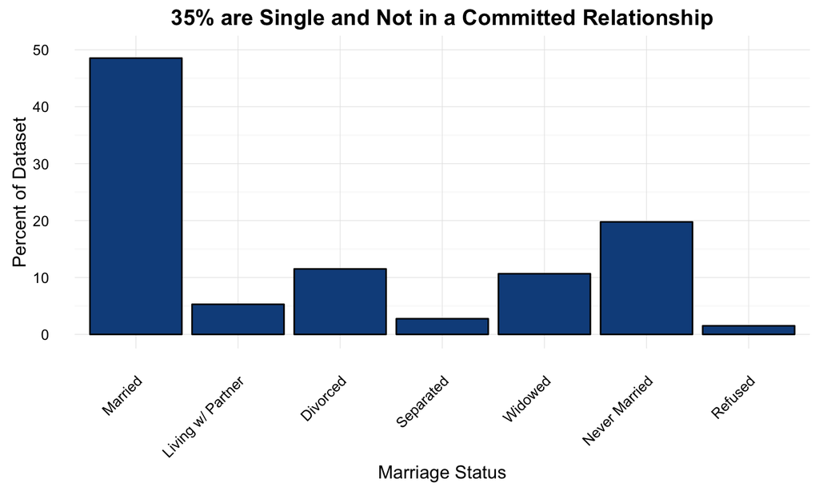

## Singles Looking for Romance

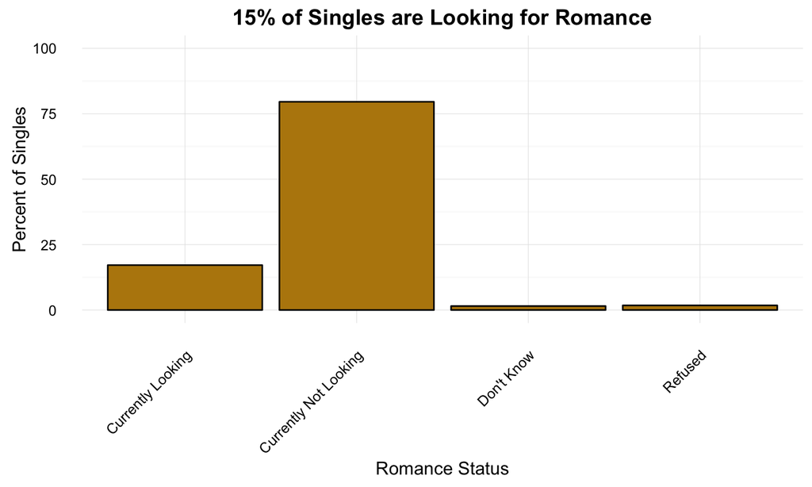

## Who is Online Dating

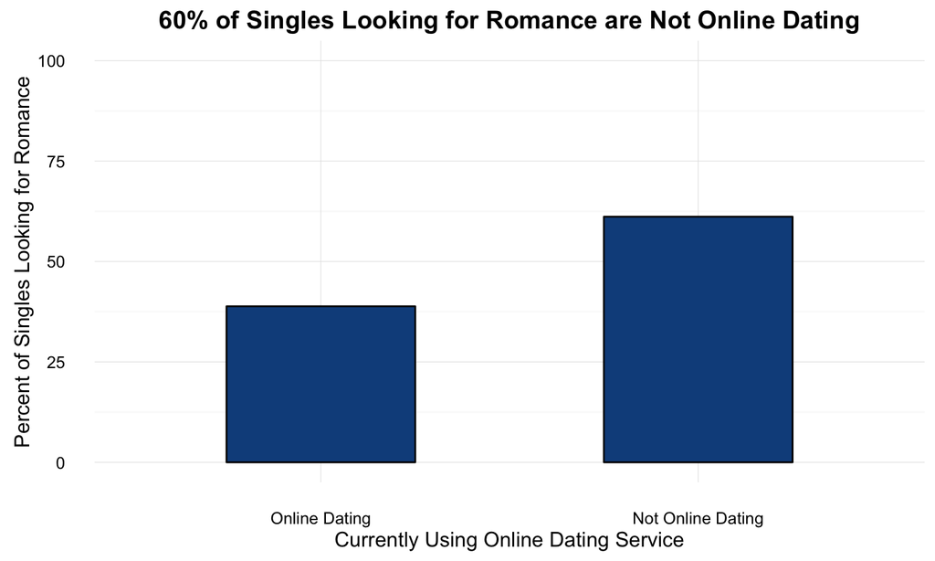

## The Target By Gender

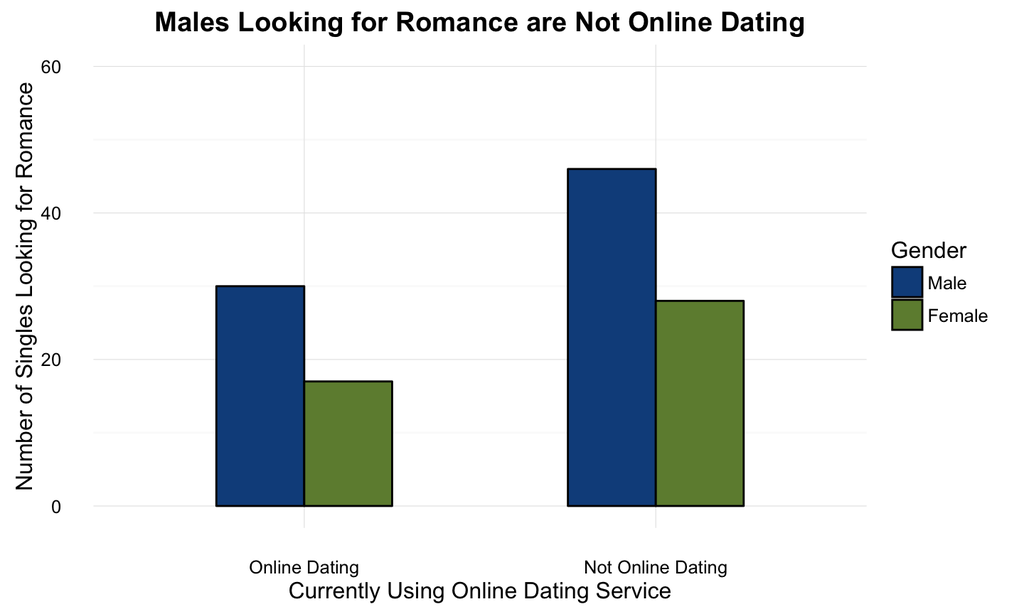

## The Target By Age

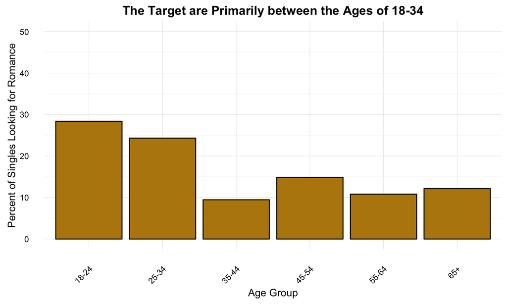

## The Target By Education

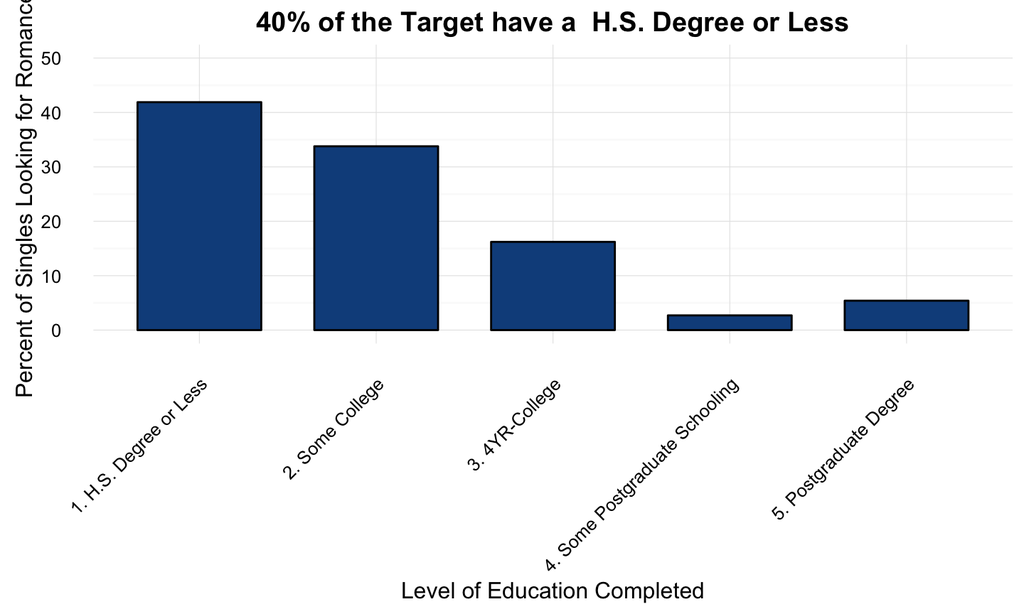

## The Target By Ethnicity

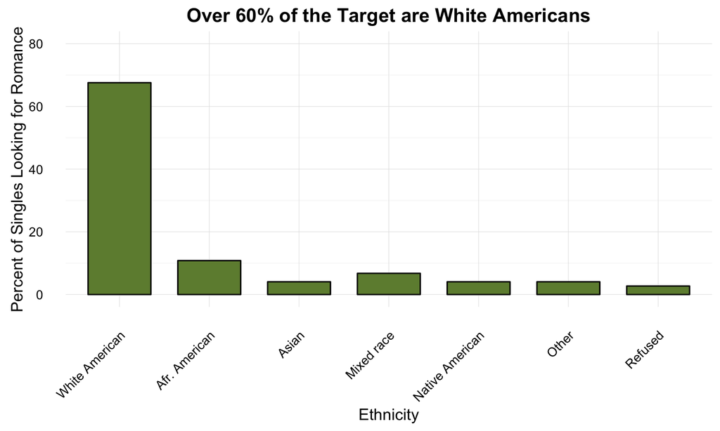

## Conclusions:

- 60% of singles looking for romance are currently not using Online Dating sites.
- From this group it seems the target are adults who fall in the following groups:
- Gender: Males
- Age: Between the ages of 18-34
- Education: With a H.S. Degree or less
- Ethnicity: White American

## Next Steps:

- Analyze the main location of the target; is it a possible regional market?
- Search for data released in the last year, compare the findings
- Look for possible relationships between other variables